# 16. 로지스틱 회귀

```python
from os.path import basename, exists

def download(url):
    filename = basename(url)
    if not exists(filename):
        from urllib.request import urlretrieve
        local, _ = urlretrieve(url, filename)
        print('Downloaded ' + local)

download('https://github.com/AllenDowney/ThinkBayes2/raw/master/soln/utils.py')

from utils import set_pyplot_params
set_pyplot_params()
```

## 16.01. 로그 오즈

> 1명의 여학생이 입장

> 1명의 여학생이 추가적으로 입장

> 1명의 여학생이 추가적으로 입장

#### 해당 강의가 수강생의 83%가 남성인 강의라고 할 수 있는가?

### 베이즈 규칙을 로그 스케일로 표현

- **$H$ : 해당 강의는 수강생의 83%가 남성인 강의라는 가설**
- **$F$ : 처음으로 입장한 학생이 여학생인 관측**

  베이즈 규칙으로 표현

$$O(H|F) = O(H) \frac{P(F|H)}{P(F|not H)}$$

- **다른 학생이 입장하는 것을 보기 전까지는, 가설에 대한 확신이 존재**

  **$\rightarrow$ 사전 공산은 10:1로 가정**

$$O(H) = \frac{10/11}{1/11}=10$$

- **만약 가설이 맞다면, 첫 입장 학생이 여자일 가능도는 17%**
- **만약 가설이 옳지 않다면, 첫 입장 학생이 여학생일 가능도는 50% 이상이라고 가정**

$$\frac{P(F|H)}{P(F|not H)} = \frac{17/100}{50/100} = 17 / 50 \simeq 1/3$$

**가능도비는 약 1/3**

- **1명의 여학생이 입장한 후, 사후 공산은**

$$O(H|F) = 10 \times 17 / 50 = 17 / 5 \simeq10/3$$

- **2명의 여학생이 입장한 후, 사후 공산은**

$$O(H|FF) = O(H) \frac{P(FF|H)}{P(FF |not H)} = 10 \times 17^2 / 50^2 \simeq 10 / 9$$

- **3명의 여학생이 입장한 후, 사후 공산은**

$$O(H|FFF) = O(H) \frac{P(FFF|H)}{P(FFF |not H)} = 10 \times 17^3 / 50^3 \simeq 10 / 27$$

*위 결과를 테이블로 표현*

```python
def prob(o):
    return o / (o+1)
```

```python
import pandas as pd

index = ['prior', '1 student', '2 students', '3 students']

table = pd.DataFrame(index=index)
table['odds'] = [10, 10/3, 10/9, 10/27]
table['prob'] = prob(table['odds'])
table['prob diff'] = table['prob'].diff() * 100
table.fillna('--')
```

|  | odds | prob | prob diff |
| --- | --- | --- | --- |
| prior | 10.000000 | 0.909091 | -- |
| 1 student | 3.333333 | 0.769231 | -13.986014 |
| 2 students | 1.111111 | 0.526316 | -24.291498 |
| 3 students | 0.370370 | 0.270270 | -25.604552 |

### 가설에 대하여 의심이 필요

#### 첫 갱신에서는 14%가량 감소했으나, 두 번째 갱신에서는 24%, 세 번째 갱신에서는 26%가 감소

- **각 갱신 시 공산에 동일한 가능도비를 곱하므로, 공산은 기하 수열 형태가 됨**

#### 오즈에 자연로그를 취한 `log odds`와 `log odds`의 변화량

- **확률이 0.5보다 큰 경우, 공산은 1보다 크고, 로그 공산은 양수**
- **확률이 0.5보다 작은 경우, 공산은 1보다 작고, 로그 공산은 음수**
- **로그 공산끼리는 동일한 차이를 가짐** **(갱신 후 로그 공산은 가능도비의 로그값 만큼 변함)**

```python
import numpy as np

table['log odds'] = np.log(table['odds'])
table['log odds diff'] = table['log odds'].diff()
table.fillna('--')
```

|  | odds | prob | prob diff | log odds | log odds diff |
| --- | --- | --- | --- | --- | --- |
| prior | 10.000000 | 0.909091 | -- | 2.302585 | -- |
| 1 student | 3.333333 | 0.769231 | -13.986014 | 1.203973 | -1.098612 |
| 2 students | 1.111111 | 0.526316 | -24.291498 | 0.105361 | -1.098612 |
| 3 students | 0.370370 | 0.270270 | -25.604552 | -0.993252 | -1.098612 |

```python
np.log(1/3)
```

```
-1.0986122886681098
```

#### 양 변에 로그를 취하여 확인

$$\log O(H|F) = \log O(H) + \log \frac{P(F|H)}{P(F|not H)}$$

- **로그 공산 상태에서, 베이지안 갱신은 '가산 형태'**

  **따라서 만약 강의실에 $x$명의 여학생이 입장했다면, 가설 $H$가 옳을 사후 공산은**

$$\log O(H|F^x) = \log O(H) + x \log \frac{P(F|H)}{P(F|not H)}$$

#### 따라서, 로그 가능도비와 사후 로그 공산 간에 선형 관계가 존재함을 확인

- **선형 등식이 정확히 성립하지 않은 경우에도, 관측변수 $x$와 다음과 같은 로그 공산으로 나타나는 종속변수 간의 관계를 보통 선형 함수로 표현**

$$\log O(H | x) = \beta_0 + \beta_1 x$$

- **$\beta_0$과 $\beta_1$는 불특정 매개변수**
  - $\beta_0$ : 절편, $x=0$일 때의 가설의 로그 공산 값
  - $\beta_1$ : 기울기, 가능도비의 로그

#### 위의 등식이 로지스틱 회귀의 기본 구조

## 16.02. 우주 왕복선 예제

[프로그래머를 위한 베이지안 with 파이썬](http://nbviewer.jupyter.org/github/CamDavidsonPilon/Probabilistic-Programming-and-Bayesian-Methods-for-Hackers/blob/master/Chapter2_MorePyMC/Ch2_MorePyMC_PyMC2.ipynb)의 문제

> 1986년 1월 28일, 미국 우주 왕복선 프로그램의 25번째 비행이 사고로 종료

> 챌린저호의 보조추진로켓 중 하나가 발사 직후 폭발하면서, 7명의 비행사가 사망

> 사고 원인 분석 대통령 직속 위원회에서, 이 사고는 보조추진로켓의 이음 부분에 있는 O링에 문제가 생겼기 때문이며, 이 문제는 O링이 외부 온도 및 여러 요인에 극도로 민감하게 설계되었기 때문이라고 결론

> 이전 24회의 비행에서, O링 문제에 대한 데이터는 23회가 기록되어 있었고 (한번은 바다로 추락), 이 데이터는 챌린저호 발사를 앞둔 저녁에는 논의가 되었으나, 불행히도 손상사고가 발생한 7편의 항공편에 해당하는 데이터만 중요하게 다뤄졌고, 여기에는 뚜렷한 경향성이 나타나지 않는 것으로 판단 되었다
- [데이터](https://raw.githubusercontent.com/CamDavidsonPilon/Probabilistic-Programming-and-Bayesian-Methods-for-Hackers/master/Chapter2_MorePyMC/data/challenger_data.csv)는 아래와 같음

```python
download('https://raw.githubusercontent.com/CamDavidsonPilon/Probabilistic-Programming-and-Bayesian-Methods-for-Hackers/master/Chapter2_MorePyMC/data/challenger_data.csv')
```

```python
data = pd.read_csv('challenger_data.csv', parse_dates=[0])
data.rename(columns={'Damage Incident': 'Damage'}, inplace=True)
data.drop(labels=[3, 24], inplace=True)
data['Damage'] = data['Damage'].astype(int)

data.head()
```

|  | Date | Temperature | Damage |
| --- | --- | --- | --- |
| 0 | 1981-04-12 | 66 | 0 |
| 1 | 1981-11-12 | 70 | 1 |
| 2 | 1982-03-22 | 69 | 0 |
| 4 | 1982-01-11 | 68 | 0 |
| 5 | 1983-04-04 | 67 | 0 |

- `Date`: 발사일
- `Temperature`: 외부 온도. 화씨(F)
- `Damage`: 손상 사고가 발생: `1`, 그렇지 않으면 `0`
- 23회의 발사에서, 7번의 손상이 발생

```python
len(data), data['Damage'].sum()
```

```
(23, 7)
```

#### 온도에 따른 손상

```python
import matplotlib.pyplot as plt
from utils import decorate
```

```python
def plot_data(data):
    plt.plot(data['Temperature'], data['Damage'], 'o', label='data', color='C0', alpha=0.4)

    decorate(ylabel="Probability of damage", xlabel="Outside temperature (deg F)", title="Damage to O-Rings vs Temperature")
```

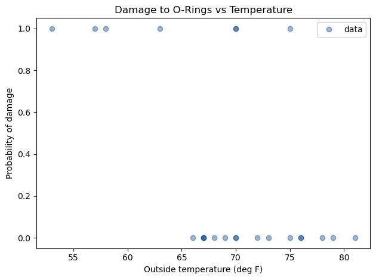

```python
plot_data(data)
```

**외부 온도가 화씨 65도 이하인 경우는 항상 손상이 발생**

**외부 온도가 화씨 65도 이상인 경우에는 보통 손상이 없었음**

$\rightarrow$ **손상 확률이 온도와 연관되었다는 가정 가능**

$$\log O(H | x) = \beta_0 + \beta_1 x$$

- $H$ : 손상이 발생한다는 가정
- $x$ : 온도

**온도는 평균이 0이 되도록 값을 조정**

```python
offset = data['Temperature'].mean().round()
data['x'] = data['Temperature'] - offset
offset
```

```
70.0
```

#### 베이지안 갱신 적용 이전, `statsmodel`를 사용하여 일반적인 (베이지안 아님) 로지스틱 회귀 적용

- 절편 값은 약 -1.2
- 추정 기울기는 약 -0.23

```python
import statsmodels.formula.api as smf
```

```python
data['y'] = data['Damage']
```

```python
formula = 'y ~ x'
results = smf.logit(formula, data=data).fit(disp=False)
results.params
```

```
Intercept   -1.208490
x           -0.232163
dtype: float64
```

#### 온도별 확률 계산 (확률 예측치)

#### `scipy.special.expit()`

- 각 온도별 로그 공산

```python
inter = results.params['Intercept']
slope = results.params['x']
xs = np.arange(53, 83) - offset
```

```python
log_odds = inter + slope * xs
```

- 로그 공산에 지수를 취하여 **확률 예측치 계산**

#### `scipy.special.expit(로그오즈)`

```python
from scipy.special import expit
```

```python
ps = expit(log_odds)

# odds = np.exp(log_odds)
# ps = odds / (odds + 1)
```

#### 온도별 손상 확률

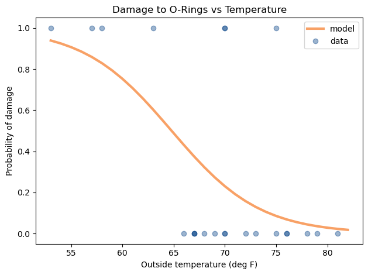

```python
plt.plot(xs+offset, ps, label='model', color='C1')

plot_data(data)
```

#### 낮은 온도에서, 손상 확률은 높고, 높은 온도에서는 0 부근까지 낮아짐

### 위 결과는 전통적인 로지스틱 회귀 방식

## 사전분포

#### 상한과 하한을 선택하기 위하여, 두 매개변수(절편, 계수)에 대해 각각 -5 ~ 1과 -0.8 ~ 0.1 범위를 가지는 사전균일분포 생성

```python
from utils import make_uniform
```

```python
qs = np.linspace(-5, 1, num=101)
prior_inter = make_uniform(qs, 'Intercept')
```

```python
qs = np.linspace(-0.8, 0.1, num=101)
prior_slope = make_uniform(qs, 'Slope')
```

#### 결합분포 생성

```python
from utils import make_joint
from empiricaldist import Pmf
```

```python
joint = make_joint(prior_inter, prior_slope)
```

```python
joint_pmf = Pmf(joint.stack())
joint_pmf.head()
```

| Slope | Intercept | probs |
| --- | --- | --- |
| -0.8 | -5.00 | 0.000098 |
|  | -4.94 | 0.000098 |
|  | -4.88 | 0.000098 |

## 16.04. 가능도

#### 갱신을 위하여, 매개변수의 가능한 쌍을 구함

- **각 온도 별로 발사 합 (`count`)과 손상 건수 합 (`sum`)을 집계**

```python
grouped = data.groupby('x')['y'].agg(['count', 'sum'])
grouped.head()
```

| x | count | sum |
| --- | --- | --- |
| -17.0 | 1 | 1 |
| -13.0 | 1 | 1 |
| -12.0 | 1 | 1 |
| -7.0 | 1 | 1 |
| -4.0 | 1 | 0 |

```python
ns = grouped['count'] # 온도별 발사 횟수
ks = grouped['sum'] # 온도별 손상 횟수
```

#### 앞서 추정한 매개변수 `slope`와 `inter`의 값이 정확하다고 가정한 후, 데이터의 가능도를 계산

- 각 온도별 손상 사고 확률 추정치

```python
xs = grouped.index # 온도
ps = expit(inter + slope * xs) # 확률 추정치
```

#### 각 온도별 발사 합과 손상 건수 합으로 데이터의 가능도를 계산

- 손상 확률이 $p$인 경우, $n$회의 발사에서 $k$회의 손상이 발생할 확률값

```python
from scipy.stats import binom
```

```python
likes = binom.pmf(ks, ns, ps)
likes
```

```
array([0.93924781, 0.85931657, 0.82884484, 0.60268105, 0.56950687,
       0.24446388, 0.67790595, 0.72637895, 0.18815003, 0.8419509 ,
       0.87045398, 0.15645171, 0.86667894, 0.95545945, 0.96435859,
       0.97729671])
```

```python
likes.prod()
```

```
0.0004653644508250071
```

#### 모든 가능한 쌍에 대한 데이터의 가능도 계산

```python
likelihood = joint_pmf.copy()

for slope, inter in joint_pmf.index:

    ps = expit(inter + slope * xs)
    likes = binom.pmf(ks, ns, ps)
    likelihood[slope, inter] = likes.prod()
```

## 16.05. 갱신

#### 사후확률 계산

```python
posterior_pmf = joint_pmf * likelihood
posterior_pmf.normalize()
```

```
3.508992289655617e-05
```

#### 각 매개변수별 가장 확률이 높은 값

```python
pd.Series(posterior_pmf.max_prob(), index=['slope', 'inter'])
```

```
slope   -0.233
inter   -1.220
dtype: float64
```

#### 전통적인 로지스틱 회귀 추정치와의 비교

```python
results.params
```

```
Intercept   -1.208490
x           -0.232163
dtype: float64
```

#### 등고선 시각화

- `slope`와 `inter` 매개변수 간 양의 상관관계가 존재함을 확인하였지만

  이는 앞서 온도의 평균값이 0이 되도록 조정을 하였기 때문

  ```
  offset = data['Temperature'].mean().round()
  data['x'] = data['Temperature'] - offset
  ```

```python
from utils import plot_contour
```

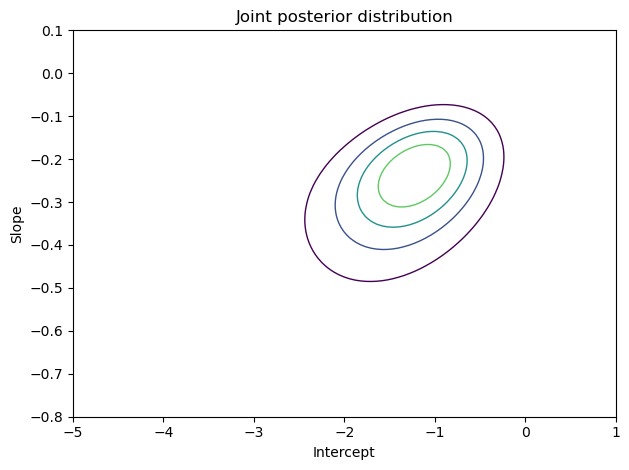

```python
joint_posterior = posterior_pmf.unstack()
plot_contour(joint_posterior)
decorate(title='Joint posterior distribution')
```

### 만약 온도의 평균값이 0이 아닌, 10이 되도록 조정하여 로지스틱 회귀를 적용하였다면? (offset = 60)

- **기울기 추정치는 동일하지만, 절편 추정치는 달라짐**

  **또한, 이 값으로 결합분포를 그래프로 그리면, 타원은 더 가늘고 길어져, 더 강한 상관관계가 있음을 확인할 수 있을 것**
- **이론적으로, 이 상관관계는 문제가 되지 않지만, 현실적으로 불확실한 데이터를 사용하는 경우 사후분포는 더 분산되어 있으므로,**

  **사후결합분포에서 이를 다 포함하기는 어려움**

  **따라서, 데이터 중심화는 추정치의 정확도를 극대화하고, 중심화되어 있지 않은 데이터로 이 정도의 정확도를 얻으려면 더 많은 계산이 필요**

## 16.06. 주변분포

```python
from utils import marginal
```

```python
marginal_inter = marginal(joint_posterior, 0)
marginal_slope = marginal(joint_posterior, 1)
```

#### `inter`의 사후주변분포

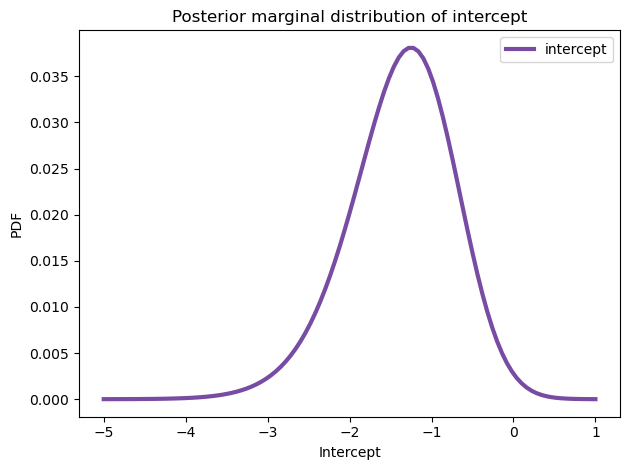

```python
marginal_inter.plot(label='intercept', color='C4')

decorate(xlabel='Intercept', ylabel='PDF', title='Posterior marginal distribution of intercept')
```

#### `slope`의 사후주변분포

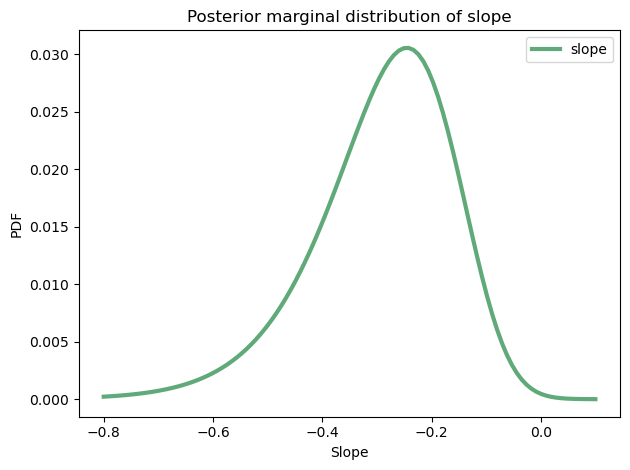

```python
marginal_slope.plot(label='slope', color='C2')

decorate(xlabel='Slope', ylabel='PDF', title='Posterior marginal distribution of slope')
```

#### 각 사후주변분포의 평균

```python
pd.Series([marginal_inter.mean(), marginal_slope.mean()], index=['inter', 'slope'])
```

```
inter   -1.376107
slope   -0.289795
dtype: float64
```

- 사후 평균과 전통적인 로지스틱 회귀 추정치간 차이가 존재

```python
results.params
```

```
Intercept   -1.208490
x           -0.232163
dtype: float64
```

## 16.07. 분포변환

### 매개변수 해석

#### `inter`

- **절편 (`inter`)은 $x$가 0, 즉 온도가 화씨 70도인 경우인 가설에 대한 로그 공산**

  **$\rightarrow$ `inter`의 사후주변분포 값도 로그 공산으로 해석 가능**

$$\log O(H|x) = \log O(H) + x \log \frac{P(x|H)}{P(x|not H)} = \beta_0 + \beta_1 x$$$$if\;x=0\;\;\;\rightarrow\;\;\;O(H | x=0)=exp(\beta_0)$$

#### `Pmf객체.transform(함수)` : Pmf객체에 `함수`를 적용하여 변환

```python
marginal_probs = marginal_inter.transform(expit)
```

#### 화씨 70도에서의 손상 확률에 대한 사후분포

- 분포의 평균값은 약 22%

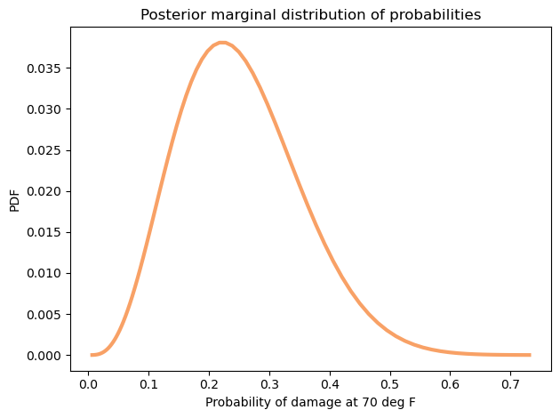

```python
marginal_probs.plot(color='C1')

decorate(xlabel='Probability of damage at 70 deg F', ylabel='PDF', title='Posterior marginal distribution of probabilities')
```

```python
mean_prob = marginal_probs.mean()
mean_prob
```

```
0.2201937884647988
```

#### `slope`

- **로지스틱 모델에서, $\beta_1$은 가능도비의 로그**

  $$\log O(H|x) = \log O(H) + x \log \frac{P(x|H)}{P(x|not H)} = \beta_0 + \beta_1 x$$

  **$\rightarrow$ `slope`의 사후주변분포 값을 로그 가능도비로 해석 가능**
- 분포 변환

```python
marginal_lr = marginal_slope.transform(np.exp)
```

#### 가능도비의 사후분포

- **분포의 평균은 0.75로, 각각 추가되는 온도는 가능도비(베이즈 요인) 0.75의 가능도로 손상 확률에 대한 증거를 제공**

  (**온도가 1도 증가할 수록, 손상사고 오즈가 25% 감소**)

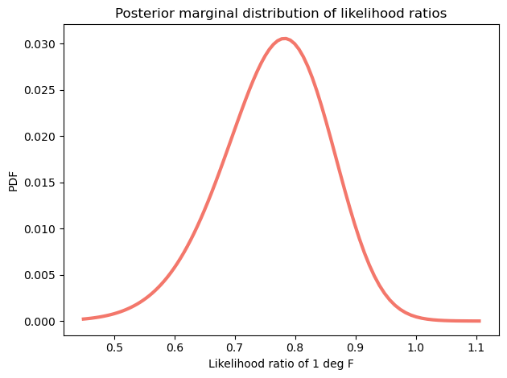

```python
marginal_lr.plot(color='C3')

decorate(xlabel='Likelihood ratio of 1 deg F', ylabel='PDF', title='Posterior marginal distribution of likelihood ratios')
```

```python
mean_lr = marginal_lr.mean()
mean_lr
```

```
0.7542914170110268
```

### 위 과정의 유의사항

1. **절편의 주변분포를 확률의 주변분포로 변환 후, 평균을 구하는 방식. $\rightarrow$ 화씨 70도일 때의 확률에 대한 사후분포 평균을 구함**
2. **기울기의 주변분포를 가능도비의 주변분포로 변환 후 평균을 구하는 방식. $\rightarrow$ 가능도비의 사후분포의 평균을 구함**

#### (사후평균을 먼저 구하고 이를 변환하는 것이 아님)

## 16.08. 예측분포

### 우주왕복선 문제에서 가장 중요한 예측은, '만약 바깥온도가 화씨 31도일 때 손상확률은 얼마인가?'

#### 사후분포에서 매개변수 쌍에서 101개의 표본 추출

```python
np.random.seed(17)
```

```python
sample = posterior_pmf.choice(101)
```

```python
temps = np.arange(31, 83)
xs = temps - offset
```

#### 101개의 매개변수 조합 표본별, 온도 범위에서의 확률 예측

```python
pred = np.empty((len(sample), len(xs)))

for i, (slope, inter) in enumerate(sample):
    pred[i] = expit(inter + slope * xs)
```

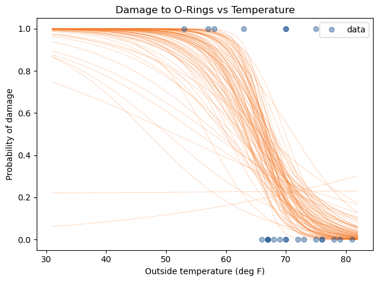

```python
for ps in pred:
    plt.plot(temps, ps, color='C1', lw=0.5, alpha=0.4)

plot_data(data)
```

#### 101개의 매개변수 조합들에 의한 예측치에 대하여, 5% 분위수, 중앙값, 95% 분위수 (= 90% 신용구간)

```python
low, median, high = np.percentile(pred, [5, 50, 95], axis=0)
```

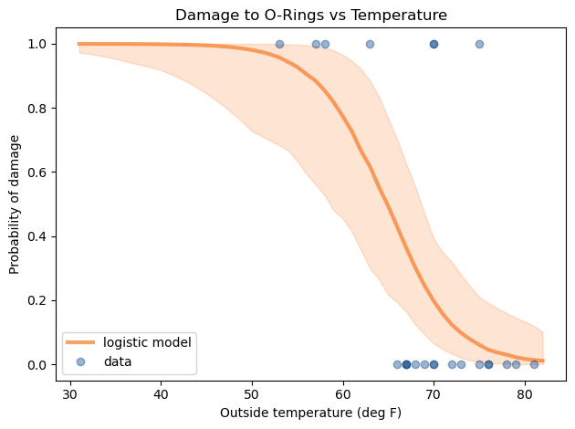

```python
plt.fill_between(temps, low, high, color='C1', alpha=0.2)
plt.plot(temps, median, color='C1', label='logistic model')

plot_data(data)
```

```python
low = pd.Series(low, temps)
median = pd.Series(median, temps)
high = pd.Series(high, temps)
```

```python
t = 80
print(median[t], (low[t], high[t]))
```

```
0.016956535510200765 (0.000563939208692237, 0.1335417225332125)
```

```python
t = 60
print(median[t], (low[t], high[t]))
```

```
0.7738185742694538 (0.45512110762641983, 0.9654437697137236)
```

```python
t = 31
print(median[t], (low[t], high[t]))
```

```
0.9998129598124814 (0.97280101769455, 0.999999987740933)
```

#### 화씨 31도에서 손상확률은 최소 97%

### 따라서,

#### 화씨 31도에서의 발사 결정은 좋지 않은 결정

#### 7개의 손상사고 데이터만이 아닌, 모든 데이터들을 고려해 보았다면, 화씨 31도에서 사고확률을 예측 할 수 있었을 것이다

## 16.09. 실증적 베이지안 방법론

#### 이 장에서 `statsmodels`를 사용하여 데이터의 확률을 최대로 만드는 매개변수를 구하고, 이 추정값을 사용해서 사전균등분포의 범위를 결정

- **위 과정에서 데이터를 2번 사용**
- **한 번은 사전분포를 구할 때 (= 로지스틱 회귀 적합),**

  **다른 한번은 베이지안 갱신 과정**

  **$\rightarrow$ [실증적 베이지안 방법론](https://en.wikipedia.org/wiki/Empirical_Bayes_method)**
- **전통적 로지스틱 회귀를 적합하지 않고 (= 추정 매개변수를 활용), 사전분포의 범위를 정하는 대신, 보다 넓은 범위의 균등분포를 사용한다면,**

  **결과는 동일하겠지만, 사전분포를 정의할 때 고려하지 않아도 되는 범위까지 고려함으로 써 계산량이 증가하게 됨**

## 16.11. 예제

### (1)

한 정치 전문가가 선거 결과를 예측할 수 있다고 주장했다고 하자. 당선자를 고르는 대신, 각 후보가 당선된 확률을 내놓았다. 이런 방식의 예측은 맞았는지 틀렸는지의 여부를 판단하기는 어려움

만약 전문가가 A가 B를 이길 확률이 70%라 했으나, B가 선거에서 당선되었다면 이 전문가는 틀린 것인가?

**이 의문에 대해 답할 수 있는 한 가지 방법은 다음 2개의 가설을 고려하는 것**

1. $H_0$ : 전문가의 알고리즘은 타당.
2. $H_1$ : 전문가의 알고리즘은 타당하지 않음 (모든 당선 확률은 임의의 확률 50%를 가짐)

**만약 전문가가 A의 당선 확률이 70%이라 하고, 실제로 A가 당선되었다면, $H_0$에 대한 가능도비 70/50의 증거가 생긴 것** **만약 전문가가 A의 당선 확률이 70%이라 하고, 실제로 A가 낙선되었다면, $H_1$에 대한 가능도비 50/30의 증거가 생긴 것**

**이 알고리즘에 대해 신뢰를 가지고 있어서, 사전 공산은 4대 1이고, 전문가가 다음과 같은 예측을 내놓았을 때, 로그 가능도비는? 사후공산은?**

**이 각각의 결과로 인하여 전문가의 신뢰가 상승했는가?**

> 첫 선거에서, A는 70%의 확률로 당선될 것이라고 했고, 실제로 당선됨

> 두 번째 선거에서, B는 30%의 확률로 당선될 것이라고 했고, 실제로 당선됨

> 세 번째 선거에서, C는 90%의 확률로 당선될 것이라고 했고, 실제로 당선됨

*[해당 주제에 대한 추가 정보](http://allendowney.blogspot.com/2016/11/why-are-we-so-surprised.html).*

#### 사전공산 : $O(H) = 4$

```python
prior_log_odds = np.log(4)
prior_log_odds
```

```
1.3862943611198906
```

#### 로그 가능도비

```python
lr1 = np.log(7/5)
lr2 = np.log(3/5)
lr3 = np.log(9/5)

lr1, lr2, lr3
```

```
(0.3364722366212129, -0.5108256237659907, 0.5877866649021191)
```

#### 사후공산 : $log O(H|x_1, x_2, x_3) = log O(H) + log \frac{P(x_1|H_{A0})}{P(x_1|not H_{A1})} + log \frac{P(x_2|H_{B0})}{P(x_2|not H_{B1})} + log \frac{P(x_3|H_{C0})}{P(x_1|not H_{C1})}$

```python
posterior_log_odds = prior_log_odds + lr1 + lr2 + lr3
posterior_log_odds
```

```
1.7997276388772319
```

```python
posterior_log_odds / (posterior_log_odds+1)
```

```
0.6428223995384681
```

### (2)

["주의력결핍 과잉행동장애와 입학월"](https://www.nejm.org/doi/10.1056/NEJMoa1806828)이라는 글에서, ADHD의 진단 확률을 태어난 월별로 살펴본 연구결과를 내놓았다

유치원 입학 기준이 9월인 주의 경우, 6, 7, 8월에 태어난 아이들이 9월에 태어난 어린이들에 비해 ADHD로 진단받는 경향이 다소 높다는 결과를 찾아냈다. 이런 주에서는 8월에 태어난 아이들이 9월에 태어난 어린이들보다 약 1년 먼저 입학하게 된다. 저자는 ADHD의 원인이 '어린이들이 어린 정도보다 ADHD를 유발할 수 있는 행동의 연령 기반 변이'에 의한 것이라고 주장

#### 이때, 탄생 월별 진단 확률은?

[figure not shown]

- `n` : 1월부터 시작하여 매월 태어난 아이의 수
- `k` : ADHD 진단을 받은 아이의 수

```python
n = np.array([32690, 31238, 34405, 34565, 34977, 34415, 36577, 36319, 35353, 34405, 31285, 31617])

k = np.array([265, 280, 307, 312, 317, 287, 320, 309, 225, 240, 232, 243])
```

```python
x = np.arange(12)
n = np.roll(n, -8)
k = np.roll(k, -8)
```

```python
adhd = pd.DataFrame(dict(x=x, k=k, n=n))
adhd['rate'] = adhd['k'] / adhd['n'] * 10000
adhd
```

|  | x | k | n | rate |
| --- | --- | --- | --- | --- |
| 0 | 0 | 225 | 35353 | 63.643821 |
| 1 | 1 | 240 | 34405 | 69.757303 |
| 2 | 2 | 232 | 31285 | 74.156944 |
| 3 | 3 | 243 | 31617 | 76.857387 |
| 4 | 4 | 265 | 32690 | 81.064546 |
| 5 | 5 | 280 | 31238 | 89.634420 |
| 6 | 6 | 307 | 34405 | 89.231216 |
| 7 | 7 | 312 | 34565 | 90.264719 |
| 8 | 8 | 317 | 34977 | 90.630986 |
| 9 | 9 | 287 | 34415 | 83.393869 |
| 10 | 10 | 320 | 36577 | 87.486672 |
| 11 | 11 | 309 | 36319 | 85.079435 |

```python
def plot_adhd(adhd):
    plt.plot(adhd['x'], adhd['rate'], 'o', label='data', color='C0', alpha=0.4)

    plt.axvline(5.5, color='gray', alpha=0.2)
    plt.text(6, 64, 'Younger than average')
    plt.text(5, 64, 'Older than average', horizontalalignment='right')

    decorate(xlabel='Birth date, months after cutoff', ylabel='Diagnosis rate per 10,000')
```

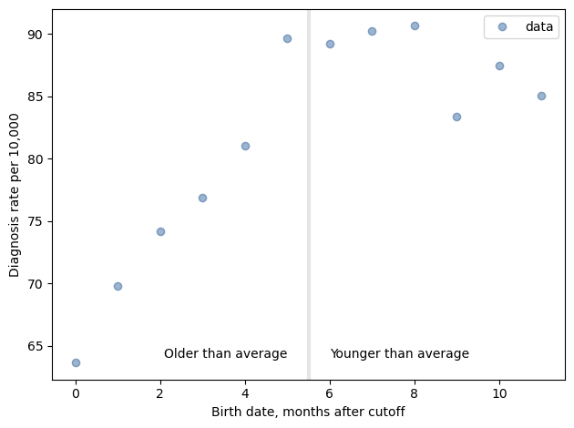

```python
plot_adhd(adhd)
```

#### 매개변수별 사전분포 설정

```python
qs = np.linspace(-5.2, -4.6, num=51)
prior_inter = make_uniform(qs, 'Intercept')
```

```python
qs = np.linspace(0.0, 0.08, num=51)
prior_slope = make_uniform(qs, 'Slope')
```

#### 결합분포 생성

```python
joint = make_joint(prior_inter, prior_slope)
joint.head()
```

| Intercept Slope | -5.200 | -5.188 | -5.176 | -5.164 | -5.152 | -5.140 | -5.128 | -5.116 | -5.104 | -5.092 | ... | -4.708 | -4.696 | -4.684 | -4.672 | -4.660 | -4.648 | -4.636 | -4.624 | -4.612 | -4.600 |
| --- | --- | --- | --- | --- | --- | --- | --- | --- | --- | --- | --- | --- | --- | --- | --- | --- | --- | --- | --- | --- | --- |
| 0.0000 | 0.000384 | 0.000384 | 0.000384 | 0.000384 | 0.000384 | 0.000384 | 0.000384 | 0.000384 | 0.000384 | 0.000384 | ... | 0.000384 | 0.000384 | 0.000384 | 0.000384 | 0.000384 | 0.000384 | 0.000384 | 0.000384 | 0.000384 | 0.000384 |
| 0.0016 | 0.000384 | 0.000384 | 0.000384 | 0.000384 | 0.000384 | 0.000384 | 0.000384 | 0.000384 | 0.000384 | 0.000384 | ... | 0.000384 | 0.000384 | 0.000384 | 0.000384 | 0.000384 | 0.000384 | 0.000384 | 0.000384 | 0.000384 | 0.000384 |
| 0.0032 | 0.000384 | 0.000384 | 0.000384 | 0.000384 | 0.000384 | 0.000384 | 0.000384 | 0.000384 | 0.000384 | 0.000384 | ... | 0.000384 | 0.000384 | 0.000384 | 0.000384 | 0.000384 | 0.000384 | 0.000384 | 0.000384 | 0.000384 | 0.000384 |
| 0.0048 | 0.000384 | 0.000384 | 0.000384 | 0.000384 | 0.000384 | 0.000384 | 0.000384 | 0.000384 | 0.000384 | 0.000384 | ... | 0.000384 | 0.000384 | 0.000384 | 0.000384 | 0.000384 | 0.000384 | 0.000384 | 0.000384 | 0.000384 | 0.000384 |
| 0.0064 | 0.000384 | 0.000384 | 0.000384 | 0.000384 | 0.000384 | 0.000384 | 0.000384 | 0.000384 | 0.000384 | 0.000384 | ... | 0.000384 | 0.000384 | 0.000384 | 0.000384 | 0.000384 | 0.000384 | 0.000384 | 0.000384 | 0.000384 | 0.000384 |

5 rows × 51 columns

```python
joint_pmf = Pmf(joint.stack())
joint_pmf.head()
```

| Slope | Intercept | probs |
| --- | --- | --- |
| 0.0 | -5.200 | 0.000384 |
|  | -5.188 | 0.000384 |
|  | -5.176 | 0.000384 |

#### 9개월 동안의 데이터

```python
num_legit = 9
adhd1 = adhd.loc[0:num_legit-1]
adhd2 = adhd.loc[num_legit:]
adhd1
```

|  | x | k | n | rate |
| --- | --- | --- | --- | --- |
| 0 | 0 | 225 | 35353 | 63.643821 |
| 1 | 1 | 240 | 34405 | 69.757303 |
| 2 | 2 | 232 | 31285 | 74.156944 |
| 3 | 3 | 243 | 31617 | 76.857387 |
| 4 | 4 | 265 | 32690 | 81.064546 |
| 5 | 5 | 280 | 31238 | 89.634420 |
| 6 | 6 | 307 | 34405 | 89.231216 |
| 7 | 7 | 312 | 34565 | 90.264719 |
| 8 | 8 | 317 | 34977 | 90.630986 |

#### 첫 번째 베이지언 갱신

- 가능도 계산

```python
likelihood1 = joint_pmf.copy()

xs = adhd1['x']
ks = adhd1['k']
ns = adhd1['n']

for slope, inter in joint_pmf.index:
    ps = expit(inter + slope * xs)
    likes = binom.pmf(ks, ns, ps)
    likelihood1[slope, inter] = likes.prod()

likelihood1.sum()
```

```
3.5436858186999676e-14
```

- 사후분포 계산

```python
posterior_pmf = joint_pmf * likelihood1
posterior_pmf.normalize()
```

```
1.3624320717800723e-17
```

```python
posterior_pmf.max_prob()
```

```
(0.0448, -4.996)
```

#### 두 번째 베이지언 갱신

- **생존 함수를 사용하여 계산 (발생횟수가 `k`보다 높을 확률)**
- 가능도 계산

```python
likelihood2 = joint_pmf.copy()

xs = adhd2['x']
ks = adhd2['k']
ns = adhd2['n']
```

```python
adhd2
```

|  | x | k | n | rate |
| --- | --- | --- | --- | --- |
| 9 | 9 | 287 | 34415 | 83.393869 |
| 10 | 10 | 320 | 36577 | 87.486672 |
| 11 | 11 | 309 | 36319 | 85.079435 |

```python
for slope, inter in joint_pmf.index:
    ps = expit(inter + slope * xs)
    likes = binom.sf(ks, ns, ps)
    likelihood2[slope, inter] = likes.prod()

likelihood2.sum()
```

```
1905.3511925074408
```

- 사후분포 계산

```python
posterior_pmf = joint_pmf * likelihood1 * likelihood2
posterior_pmf.normalize()
```

```
1.3403142132512746e-17
```

```python
posterior_pmf.max_prob()
```

```
(0.0448, -4.996)
```

#### 등고선 시각화

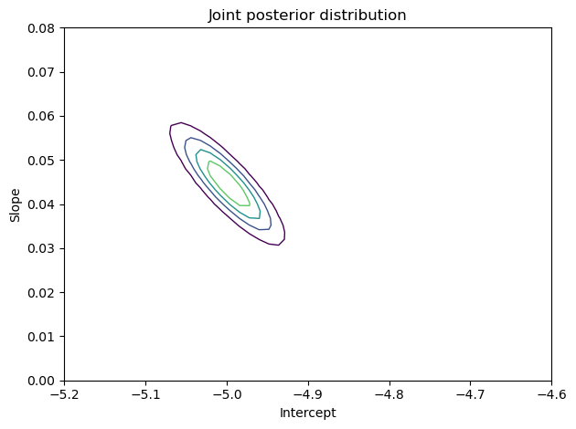

```python
joint_posterior = posterior_pmf.unstack()

plot_contour(joint_posterior)
decorate(title='Joint posterior distribution')
```

#### 매개변수별 사후주변분포 계산

```python
marginal_inter = marginal(joint_posterior, 0)
marginal_slope = marginal(joint_posterior, 1)

marginal_inter.mean(), marginal_slope.mean()
```

```
(-4.999322906782617, 0.04460761677198374)
```

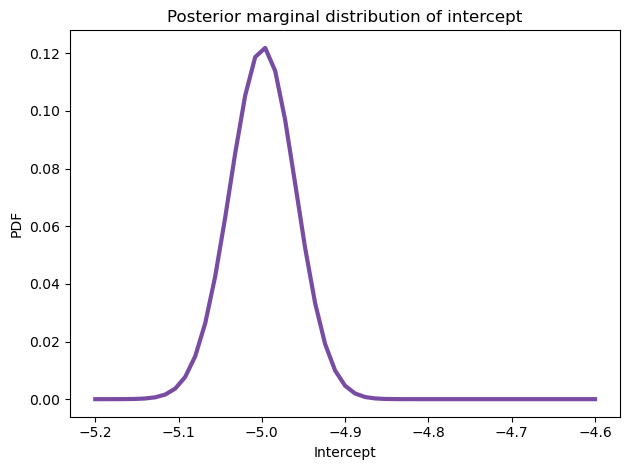

```python
marginal_inter.plot(color='C4')
decorate(xlabel='Intercept', ylabel='PDF', title='Posterior marginal distribution of intercept')
```

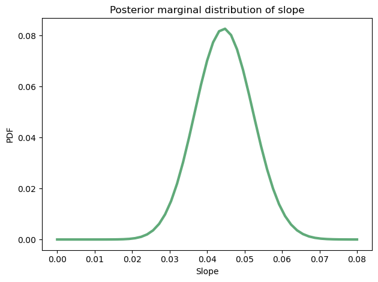

```python
marginal_slope.plot(color='C2')

decorate(xlabel='Slope', ylabel='PDF', title='Posterior marginal distribution of slope')
```

#### 사후분포에서 매개변수 쌍에 대한 표본을 추출하고, 각 매개변수 쌍별 예측값 계산

```python
sample = posterior_pmf.choice(101)
xs = adhd['x']
ps = np.empty((len(sample), len(xs)))

for i, (slope, inter) in enumerate(sample):
    ps[i] = expit(inter + slope * xs)

ps.shape
```

```
(101, 12)
```

```python
low, median, high = np.percentile(ps, [2.5, 50, 97.5], axis=0)
median
```

```
array([0.0067195 , 0.00700292, 0.00730402, 0.00764219, 0.00797687,
       0.00835919, 0.00873192, 0.00908504, 0.0094748 , 0.00990462,
       0.01035374, 0.01077173])
```

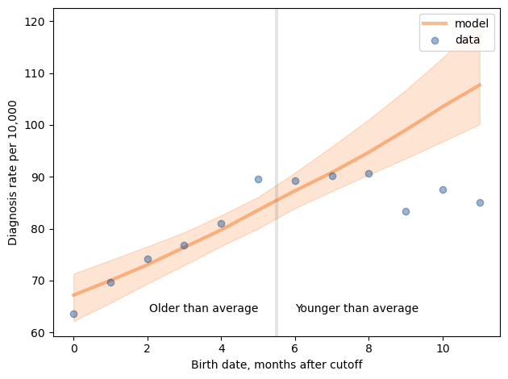

```python
plt.fill_between(xs, low*10000, high*10000, color='C1', alpha=0.2)

plt.plot(xs, median*10000, label='model', color='C1', alpha=0.5)

plot_adhd(adhd)
```